# Compulsory exercise 3

TMA4268 Statistical Learning V2021

Dilawar Mahmood

24 mai, 2021

# Problem 1

```r
library(ISLR)
library(keras)
set.seed(1)
College$Private = as.numeric(College$Private)
train.ind = sample(1:nrow(College), 0.5 * nrow(College))
college.train = College[train.ind, ]
college.test = College[-train.ind, ]
str(College)
```

```
## 'data.frame':    777 obs. of  18 variables:
##  $ Private    : num  2 2 2 2 2 2 2 2 2 2 ...
##  $ Apps       : num  1660 2186 1428 417 193 ...
##  $ Accept     : num  1232 1924 1097 349 146 ...
##  $ Enroll     : num  721 512 336 137 55 158 103 489 227 172 ...
##  $ Top10perc  : num  23 16 22 60 16 38 17 37 30 21 ...
##  $ Top25perc  : num  52 29 50 89 44 62 45 68 63 44 ...
##  $ F.Undergrad: num  2885 2683 1036 510 249 ...
##  $ P.Undergrad: num  537 1227 99 63 869 ...
##  $ Outstate   : num  7440 12280 11250 12960 7560 ...
##  $ Room.Board : num  3300 6450 3750 5450 4120 ...
##  $ Books      : num  450 750 400 450 800 500 500 450 300 660 ...
##  $ Personal   : num  2200 1500 1165 875 1500 ...
##  $ PhD        : num  70 29 53 92 76 67 90 89 79 40 ...
##  $ Terminal   : num  78 30 66 97 72 73 93 100 84 41 ...
##  $ S.F.Ratio  : num  18.1 12.2 12.9 7.7 11.9 9.4 11.5 13.7 11.3 11.5 ...
##  $ perc.alumni: num  12 16 30 37 2 11 26 37 23 15 ...
##  $ Expend     : num  7041 10527 8735 19016 10922 ...
##  $ Grad.Rate  : num  60 56 54 59 15 55 63 73 80 52 ...
```

## a)

```r
train.data = subset(college.train, select = -c(Outstate))
train.target = college.train$Outstate

test.data = subset(college.test, select = -c(Outstate))
test.target = college.test$Outstate

mean = apply(train.data, 2, mean)
std = apply(train.data, 2, sd)
train.data = scale(train.data, center = mean, scale = std)
test.data = scale(test.data, center = mean, scale = std)
```

## b)

See notes.

## c)

**Build Model**

```r
build_model = function() {
    model = keras_model_sequential() %>%
        layer_dense(units = 64, activation = "relu", input_shape = ncol(train.data)) %>%
        layer_dense(units = 64, activation = "relu") %>%
        layer_dense(units = 1)
    model %>%
        compile(optimizer = "rmsprop", loss = "mse", metrics = c("mae"))
}
```

**Training the network**

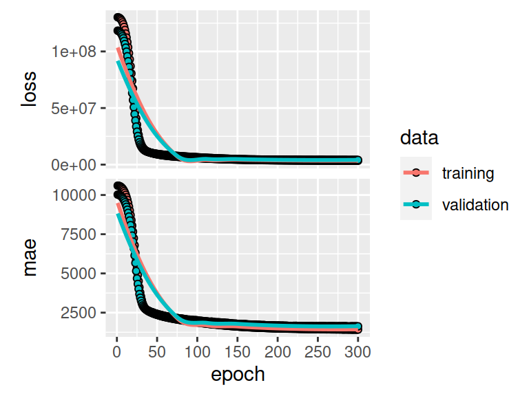

```r
set.seed(123)

model <- build_model()
history = model %>%
    fit(train.data, train.target, epochs = 300, batch_size = 8, verbose = 0, validation_split = 0.2)

plot(history)
```

```r
result = model %>%
    evaluate(test.data, test.target)
result
```

```
##        loss         mae
## 3713331.000    1526.545
```

```r
str(history)
```

```
## List of 2
##  $ params :List of 3
##   ..$ verbose: int 0
##   ..$ epochs : int 300
##   ..$ steps  : int 39
##  $ metrics:List of 4
##   ..$ loss    : num [1:300] 1.30e+08 1.30e+08 1.30e+08 1.29e+08 1.28e+08 ...
##   ..$ mae     : num [1:300] 10595 10587 10572 10549 10517 ...
##   ..$ val_loss: num [1:300] 1.18e+08 1.18e+08 1.18e+08 1.17e+08 1.16e+08 ...
##   ..$ val_mae : num [1:300] 10025 10015 9997 9971 9934 ...
##  - attr(*, "class")= chr "keras_training_history"
```

## d)

**Dropout**

```r
build_model = function() {
    model = keras_model_sequential() %>%
        layer_dense(units = 64, activation = "relu", input_shape = ncol(train.data)) %>%
        layer_dropout(rate = 0.4) %>%
        layer_dense(units = 64, activation = "relu") %>%
        layer_dropout(rate = 0.4) %>%
        layer_dense(units = 1)
    model %>%
        compile(optimizer = "rmsprop", loss = "mse", metrics = c("mae"))
}
```

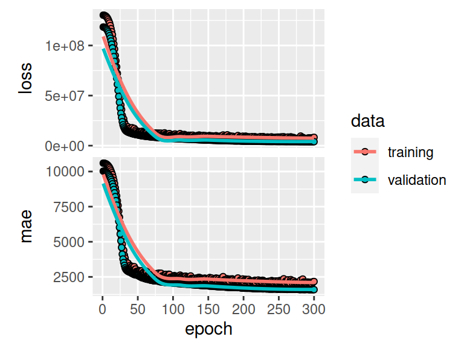

```r
# randomly allocate each sample to a particular fold
set.seed(123)

model_dropout = build_model()

history = model_dropout %>%
    fit(train.data, train.target, epochs = 300, batch_size = 8, verbose = 0, validation_split = 0.2)

plot(history)
```

```r
result = model_dropout %>%
    evaluate(test.data, test.target)
result
```

```
##        loss         mae
## 3453171.750    1474.072
```

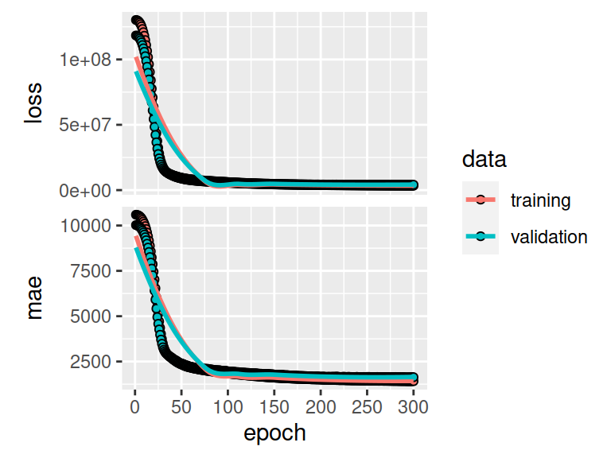

```r
build_model = function() {
    model = keras_model_sequential() %>%
        layer_dense(units = 64, activation = "relu", input_shape = ncol(train.data),
            kernel_regularizer = regularizer_l2(l = 0.001)) %>%
        layer_dense(units = 64, activation = "relu", kernel_regularizer = regularizer_l2(l = 0.001)) %>%
        layer_dense(units = 1)
    model %>%
        compile(optimizer = "rmsprop", loss = "mse", metrics = c("mae"))
}

set.seed(123)

model_l1 = build_model()

history = model_l1 %>%
    fit(train.data, train.target, epochs = 300, batch_size = 8, verbose = 0, validation_split = 0.2)

plot(history)
```

```r
result = model_l1 %>%
    evaluate(test.data, test.target)
result
```

```
##        loss         mae
## 3643026.750    1506.956
```

- It seems that dropout improves the result from c, but keep in mind that there is some variability in the result. In any case, the test MSE does not get nearly as low as for the bagging, random forests and boosted regression trees.

# Problem 2

```r
id <- "1CA1RPRYqU9oTIaHfSroitnWrI6WpUeBw"  # google file ID
d.corona <- read.csv(sprintf("https://docs.google.com/uc?id=%s&export=download",
    id), header = T)
```

## a)

```r
table(d.corona$deceased, d.corona$country)
```

```
##
##     France indonesia japan Korea
##   0    100        67   291  1507
##   1     14         2     3    26
```

```r
table(d.corona$deceased, d.corona$sex)
```

```
##
##     female male
##   0   1075  890
##   1     14   31
```

```r
France = d.corona[which(d.corona$country == "France"), ]
Japan = d.corona[which(d.corona$country == "japan"), ]
Indonesia = d.corona[which(d.corona$country == "indonesia"), ]
Korea = d.corona[which(d.corona$country == "Korea"), ]

table(France$deceased, France$sex)
```

```
##
##     female male
##   0     55   45
##   1      5    9
```

```r
table(Japan$deceased, Japan$sex)
```

```
##
##     female male
##   0    120  171
##   1      0    3
```

```r
table(Indonesia$deceased, Indonesia$sex)
```

```
##
##     female male
##   0     29   38
##   1      1    1
```

```r
table(Korea$deceased, Korea$sex)
```

```
##
##     female male
##   0    871  636
##   1      8   18
```

## b)

```r
# Logistic regression
r.glm <- glm(deceased ~ sex + age + country, d.corona, family = "binomial")
summary(r.glm)
```

```
##
## Call:
## glm(formula = deceased ~ sex + age + country, family = "binomial",
##     data = d.corona)
##
## Deviance Residuals:
##     Min       1Q   Median       3Q      Max
## -1.2797  -0.1855  -0.1009  -0.0553   3.2233
##
## Coefficients:
##                   Estimate Std. Error z value Pr(>|z|)
## (Intercept)      -7.633051   0.897063  -8.509  < 2e-16 ***
## sexmale           1.137246   0.343706   3.309 0.000937 ***
## age               0.068012   0.009846   6.907 4.94e-12 ***
## countryindonesia -0.754259   0.815127  -0.925 0.354796
## countryjapan     -2.434101   0.667826  -3.645 0.000268 ***
## countryKorea     -1.366797   0.374837  -3.646 0.000266 ***
## ---
## Signif. codes:  0 '***' 0.001 '**' 0.01 '*' 0.05 '.' 0.1 ' ' 1
##
## (Dispersion parameter for binomial family taken to be 1)
##
##     Null deviance: 430.92  on 2009  degrees of freedom
## Residual deviance: 321.07  on 2004  degrees of freedom
## AIC: 333.07
##
## Number of Fisher Scoring iterations: 8
```

```r
anova(r.glm, test = "Chisq")
```

```
## Analysis of Deviance Table
##
## Model: binomial, link: logit
##
## Response: deceased
##
## Terms added sequentially (first to last)
##
##
##         Df Deviance Resid. Df Resid. Dev  Pr(>Chi)
## NULL                     2009     430.92
## sex      1    9.969      2008     420.95 0.0015917 **
## age      1   80.567      2007     340.38 < 2.2e-16 ***
## country  3   19.313      2004     321.07 0.0002356 ***
## ---
## Signif. codes:  0 '***' 0.001 '**' 0.01 '*' 0.05 '.' 0.1 ' ' 1
```

### i)

FALSE.

### ii)

FALSE.

### iii)

FALSE. The calculation is $e^{10\cdot\beta_\text{age}}=1.97$, but it’s the odds that changes, not the odds ratio!

### iv)

FALSE, because $e^{\beta_{sex}}$ is the odds ratio, not the probability.

## c)

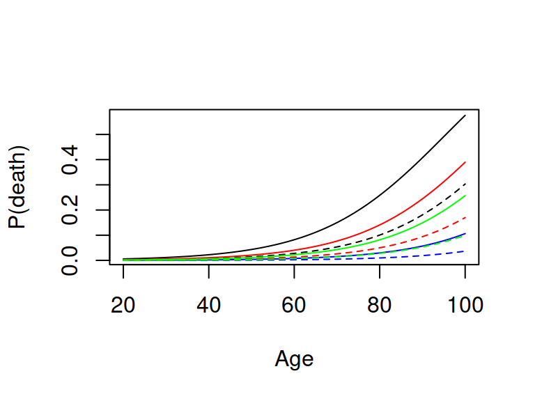

```r
x.age <- seq(20, 100, 1)

yMaleFrance = predict(r.glm, newdata = expand.grid(sex = "male", age = x.age, country = "France"),
    type = "response")
yFemaleFrance = predict(r.glm, newdata = expand.grid(sex = "female", age = x.age,
    country = "France"), type = "response")
yMaleJapan = predict(r.glm, newdata = expand.grid(sex = "male", age = x.age, country = "japan"),
    type = "response")
yFemaleJapan = predict(r.glm, newdata = expand.grid(sex = "female", age = x.age,
    country = "japan"), type = "response")
yMaleIndonesia = predict(r.glm, newdata = expand.grid(sex = "male", age = x.age,
    country = "indonesia"), type = "response")
yFemaleIndonesia = predict(r.glm, newdata = expand.grid(sex = "female", age = x.age,
    country = "indonesia"), type = "response")
yMaleKorea = predict(r.glm, newdata = expand.grid(sex = "male", age = x.age, country = "Korea"),
    type = "response")
yFemaleKorea = predict(r.glm, newdata = expand.grid(sex = "female", age = x.age,
    country = "Korea"), type = "response")

plot(x = x.age, y = yMaleFrance, type = "l", ylab = "P(death)", xlab = "Age")
lines(x.age, yFemaleFrance, col = "black", lty = 2)
lines(x.age, yMaleJapan, col = "blue")
lines(x.age, yFemaleJapan, col = "blue", lty = 2)
lines(x.age, yMaleIndonesia, col = "red")
lines(x.age, yFemaleIndonesia, col = "red", lty = 2)
lines(x.age, yMaleKorea, col = "green")
lines(x.age, yFemaleKorea, col = "green", lty = 2)
```

## d)

### i)

**Yes**, this is clearly the case, as can be seen from the model fitted under b).

### ii)

```r
mod2 = glm(deceased ~ sex + age + country + sex * age, d.corona, family = "binomial")
summary(mod2)
```

```
##
## Call:
## glm(formula = deceased ~ sex + age + country + sex * age, family = "binomial",
##     data = d.corona)
##
## Deviance Residuals:
##     Min       1Q   Median       3Q      Max
## -1.2701  -0.1861  -0.1028  -0.0563   3.2162
##
## Coefficients:
##                  Estimate Std. Error z value Pr(>|z|)
## (Intercept)      -7.77989    1.41136  -5.512 3.54e-08 ***
## sexmale           1.35802    1.65509   0.821 0.411924
## age               0.06986    0.01683   4.150 3.32e-05 ***
## countryindonesia -0.75872    0.81526  -0.931 0.352035
## countryjapan     -2.43169    0.66785  -3.641 0.000271 ***
## countryKorea     -1.36693    0.37461  -3.649 0.000263 ***
## sexmale:age      -0.00282    0.02064  -0.137 0.891338
## ---
## Signif. codes:  0 '***' 0.001 '**' 0.01 '*' 0.05 '.' 0.1 ' ' 1
##
## (Dispersion parameter for binomial family taken to be 1)
##
##     Null deviance: 430.92  on 2009  degrees of freedom
## Residual deviance: 321.05  on 2003  degrees of freedom
## AIC: 335.05
##
## Number of Fisher Scoring iterations: 8
```

**No**. The slope for women is $\beta_2$, while the slope for males is $\beta_2+\beta_6$. As we have no evidence that $\beta_6$ is different from zero ($p=0.89$), we have no evidence that age is a greater risk for males than for females.

### iii)

```r
mod3 = glm(deceased ~ sex + age + country + age * country, d.corona, family = "binomial")
summary(mod3)
```

```
##
## Call:
## glm(formula = deceased ~ sex + age + country + age * country,
##     family = "binomial", data = d.corona)
##
## Deviance Residuals:
##      Min        1Q    Median        3Q       Max
## -1.53644  -0.17938  -0.10094  -0.05524   3.16223
##
## Coefficients:
##                       Estimate Std. Error z value Pr(>|z|)
## (Intercept)          -10.35138    2.52507  -4.099 4.14e-05 ***
## sexmale                1.17341    0.34949   3.357 0.000787 ***
## age                    0.10092    0.02969   3.399 0.000676 ***
## countryindonesia       5.66073    3.33056   1.700 0.089200 .
## countryjapan           3.35895    3.31974   1.012 0.311628
## countryKorea           1.09736    2.66139   0.412 0.680100
## age:countryindonesia  -0.09372    0.04974  -1.884 0.059573 .
## age:countryjapan      -0.07559    0.04343  -1.741 0.081755 .
## age:countryKorea      -0.02991    0.03193  -0.937 0.348933
## ---
## Signif. codes:  0 '***' 0.001 '**' 0.01 '*' 0.05 '.' 0.1 ' ' 1
##
## (Dispersion parameter for binomial family taken to be 1)
##
##     Null deviance: 430.92  on 2009  degrees of freedom
## Residual deviance: 315.74  on 2001  degrees of freedom
## AIC: 333.74
##
## Number of Fisher Scoring iterations: 8
```

**No**. The slope for age for the Korean population is $\beta_2+\beta_8$, while it is $\beta_2$ for French. Given that $p=0.35$ for $\beta_8$, so there is no evidence that age is an increased risk for French with respect to Korean.

## e)

It will probably have to do with how it was tested, that is, in France only severe cases were tested, whereas asian countries have tested much more.

## f)

### i)

TRUE.

### ii)

TRUE.

### iii)

```r
sum(d.corona$deceased)/nrow(d.corona)
```

```
## [1] 0.02238806
```

TRUE.

### iv)

```r
library(MASS)
table(predict = predict(lda(deceased ~ age + sex + country, data = d.corona))$class,
    true = d.corona$deceased)
```

```
##        true
## predict    0    1
##       0 1926   31
##       1   39   14
```

TRUE.

# Problem 3

```r
id <- "1heRtzi8vBoBGMaM2-ivBQI5Ki3HgJTmO"  # google file ID
d.support <- read.csv(sprintf("https://docs.google.com/uc?id=%s&export=download",
    id), header = T)
# We only look at complete cases
d.support <- d.support[complete.cases(d.support), ]
d.support <- d.support[d.support$totcst > 0, ]
```

## a)

See notes.

## b)

```r
r.lm <- lm(log(totcst) ~ age + temp + edu + resp + num.co + dzgroup, d.support)
summary(r.lm)
```

```
##
## Call:
## lm(formula = log(totcst) ~ age + temp + edu + resp + num.co +
##     dzgroup, data = d.support)
##
## Residuals:
##     Min      1Q  Median      3Q     Max
## -6.6554 -0.6524 -0.0437  0.6203  3.5226
##
## Coefficients:
##                       Estimate Std. Error t value Pr(>|t|)
## (Intercept)          8.0823597  0.4014491  20.133  < 2e-16 ***
## age                 -0.0069950  0.0008742  -8.001 1.52e-15 ***
## temp                 0.0690123  0.0104548   6.601 4.51e-11 ***
## edu                  0.0249934  0.0039506   6.326 2.73e-10 ***
## resp                -0.0027792  0.0012791  -2.173   0.0298 *
## num.co              -0.0430856  0.0107460  -4.009 6.18e-05 ***
## dzgroupCHF          -1.3992569  0.0437688 -31.969  < 2e-16 ***
## dzgroupCirrhosis    -0.9113548  0.0645311 -14.123  < 2e-16 ***
## dzgroupColon Cancer -1.4947386  0.0842719 -17.737  < 2e-16 ***
## dzgroupComa         -0.4501610  0.0562858  -7.998 1.57e-15 ***
## dzgroupCOPD         -1.2432540  0.0441240 -28.176  < 2e-16 ***
## dzgroupLung Cancer  -1.6924699  0.0540838 -31.293  < 2e-16 ***
## dzgroupMOSF w/Malig -0.2627110  0.0510358  -5.148 2.74e-07 ***
## ---
## Signif. codes:  0 '***' 0.001 '**' 0.01 '*' 0.05 '.' 0.1 ' ' 1
##
## Residual standard error: 0.9337 on 4947 degrees of freedom
## Multiple R-squared:  0.3817, Adjusted R-squared:  0.3802
## F-statistic: 254.5 on 12 and 4947 DF,  p-value: < 2.2e-16
```

```r
anova(r.lm)
```

```
## Analysis of Variance Table
##
## Response: log(totcst)
##             Df Sum Sq Mean Sq  F value    Pr(>F)
## age          1  279.6 279.590 320.6989 < 2.2e-16 ***
## temp         1  195.0 194.988 223.6578 < 2.2e-16 ***
## edu          1   68.2  68.207  78.2354 < 2.2e-16 ***
## resp         1    6.5   6.540   7.5016  0.006186 **
## num.co       1  268.9 268.942 308.4852 < 2.2e-16 ***
## dzgroup      7 1844.0 263.431 302.1645 < 2.2e-16 ***
## Residuals 4947 4312.9   0.872
## ---
## Signif. codes:  0 '***' 0.001 '**' 0.01 '*' 0.05 '.' 0.1 ' ' 1
```

```r
r.lm2 <- lm(log(totcst) ~ age + temp + edu + resp + num.co + dzgroup * age, d.support)
summary(r.lm2)
```

```
##
## Call:
## lm(formula = log(totcst) ~ age + temp + edu + resp + num.co +
##     dzgroup * age, data = d.support)
##
## Residuals:
##     Min      1Q  Median      3Q     Max
## -6.6560 -0.6571 -0.0379  0.6180  3.5006
##
## Coefficients:
##                          Estimate Std. Error t value Pr(>|t|)
## (Intercept)              7.916235   0.405255  19.534  < 2e-16 ***
## age                     -0.004773   0.001144  -4.170 3.09e-05 ***
## temp                     0.069829   0.010450   6.682 2.61e-11 ***
## edu                      0.024749   0.003945   6.274 3.82e-10 ***
## resp                    -0.002709   0.001279  -2.118 0.034196 *
## num.co                  -0.041790   0.010740  -3.891 0.000101 ***
## dzgroupCHF              -1.038131   0.188132  -5.518 3.60e-08 ***
## dzgroupCirrhosis        -0.554501   0.257563  -2.153 0.031377 *
## dzgroupColon Cancer     -2.024012   0.536676  -3.771 0.000164 ***
## dzgroupComa              0.267332   0.216580   1.234 0.217137
## dzgroupCOPD             -1.466316   0.252269  -5.813 6.54e-09 ***
## dzgroupLung Cancer      -1.913060   0.297221  -6.436 1.34e-10 ***
## dzgroupMOSF w/Malig      0.363018   0.197146   1.841 0.065628 .
## age:dzgroupCHF          -0.005603   0.002761  -2.029 0.042516 *
## age:dzgroupCirrhosis    -0.006396   0.004624  -1.383 0.166608
## age:dzgroupColon Cancer  0.008119   0.008254   0.984 0.325305
## age:dzgroupComa         -0.011423   0.003322  -3.439 0.000589 ***
## age:dzgroupCOPD          0.002905   0.003606   0.805 0.420610
## age:dzgroupLung Cancer   0.003533   0.004734   0.746 0.455533
## age:dzgroupMOSF w/Malig -0.010539   0.003215  -3.278 0.001053 **
## ---
## Signif. codes:  0 '***' 0.001 '**' 0.01 '*' 0.05 '.' 0.1 ' ' 1
##
## Residual standard error: 0.9317 on 4940 degrees of freedom
## Multiple R-squared:  0.3852, Adjusted R-squared:  0.3828
## F-statistic: 162.9 on 19 and 4940 DF,  p-value: < 2.2e-16
```

```r
anova(r.lm2)
```

```
## Analysis of Variance Table
##
## Response: log(totcst)
##               Df Sum Sq Mean Sq  F value    Pr(>F)
## age            1  279.6 279.590 322.0778 < 2.2e-16 ***
## temp           1  195.0 194.988 224.6195 < 2.2e-16 ***
## edu            1   68.2  68.207  78.5718 < 2.2e-16 ***
## resp           1    6.5   6.540   7.5339 0.0060768 **
## num.co         1  268.9 268.942 309.8116 < 2.2e-16 ***
## dzgroup        7 1844.0 263.431 303.4637 < 2.2e-16 ***
## age:dzgroup    7   24.5   3.506   4.0387 0.0002019 ***
## Residuals   4940 4288.3   0.868
## ---
## Signif. codes:  0 '***' 0.001 '**' 0.01 '*' 0.05 '.' 0.1 ' ' 1
```

### i)

The expected costs should go down by a factor of $e^{10\cdot(-0.007)}=0.932$. Note that we need the exp-transformation to obtain the result on the scale of the costs (instead of log costs, which we used as the response).

### ii)

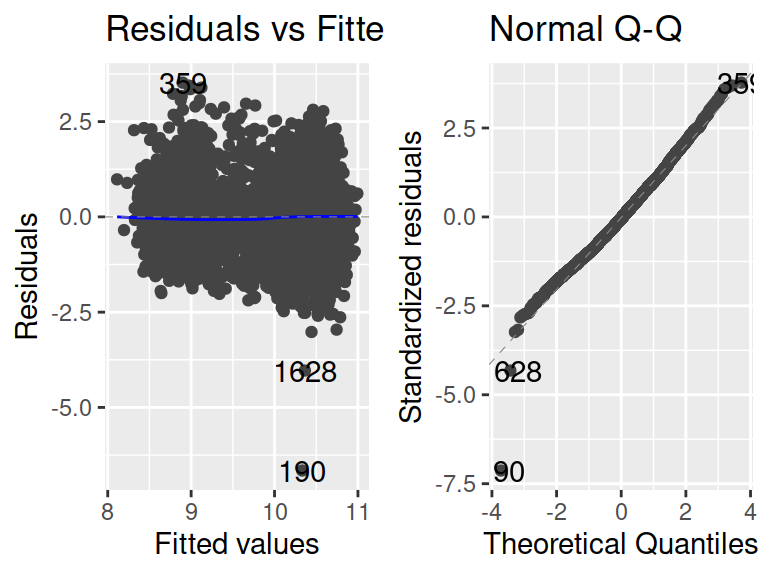

```r
library(ggfortify)
autoplot(r.lm, which = c(1, 2))
```

No violations visible.

### iii)

Yes, in the anova table we see that the $p$-value for the interaction between age and disease group is about $p=0.0002$, thus very small.

## c)

```r
set.seed(12345)
train.ind = sample(1:nrow(d.support), 0.8 * nrow(d.support))
d.support.train = d.support[train.ind, ]
d.support.test = d.support[-train.ind, ]
```

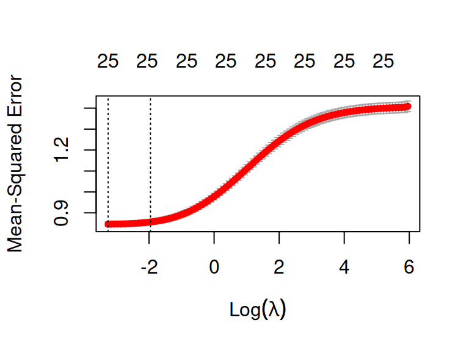

```r
library(glmnet)
x.train = model.matrix(log(totcst) ~ ., data = d.support.train)[, -1]
y.train = log(d.support.train$totcst)
set.seed(4268)
cv.ridge = cv.glmnet(x.train, y.train, alpha = 0)
plot(cv.ridge)
```

```r
(lambda.ridge = cv.ridge$lambda.1se)
```

```
## [1] 0.1415939
```

```r
r.ridge = glmnet(x.train, y.train, alpha = 0, lambda = cv.ridge$lambda.1se)
coef(r.ridge)
```

```
## 26 x 1 sparse Matrix of class "dgCMatrix"
##                                s0
## (Intercept)          8.7509876866
## age                 -0.0063660700
## dzgroupCHF          -1.0745066758
## dzgroupCirrhosis    -0.6676111932
## dzgroupColon Cancer -1.2144632825
## dzgroupComa         -0.4382669579
## dzgroupCOPD         -0.9492741087
## dzgroupLung Cancer  -1.3775286478
## dzgroupMOSF w/Malig -0.1282084246
## num.co              -0.0548536914
## edu                  0.0145426381
## income>$50k          0.1197607346
## income$11-$25k      -0.0467792620
## income$25-$50k       0.0205420134
## incomeunder $11k    -0.1932619994
## scoma                0.0034426327
## raceasian            0.2822436227
## raceblack           -0.0598678518
## racehispanic         0.1926428042
## raceother            0.0908544458
## racewhite           -0.0080991686
## meanbp               0.0002068517
## hrt                  0.0028450861
## resp                -0.0048272561
## temp                 0.0480237414
## pafi                -0.0005729920
```

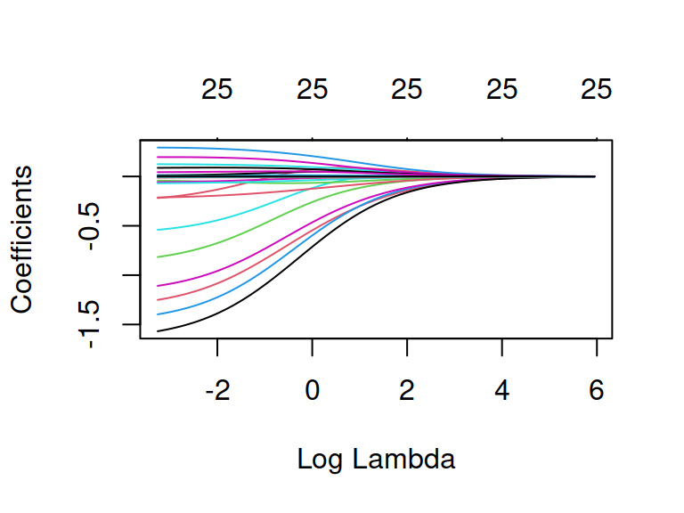

```r
plot(glmnet(x.train, y.train, alpha = 0), "lambda")
```

```r
x.test = model.matrix(log(totcst) ~ ., data = d.support.test)[, -1]
y.test = d.support.test$totcst
mse.ridge = mean((log(y.test) - predict(r.ridge, newx = x.test))^2)
mse.ridge
```

```
## [1] 0.874485
```

## d)

```r
library(pls)
set.seed(234)
r.pls <- plsr(log(totcst) ~ ., data = d.support.train, scale = T, validation = "CV")
summary(r.pls)
```

```
## Data:    X dimension: 3968 25
##  Y dimension: 3968 1
## Fit method: kernelpls
## Number of components considered: 25
##
## VALIDATION: RMSEP
## Cross-validated using 10 random segments.
##        (Intercept)  1 comps  2 comps  3 comps  4 comps  5 comps  6 comps
## CV           1.187   0.9969   0.9366   0.9226   0.9193   0.9191   0.9190
## adjCV        1.187   0.9967   0.9361   0.9223   0.9190   0.9188   0.9187
##        7 comps  8 comps  9 comps  10 comps  11 comps  12 comps  13 comps
## CV      0.9190   0.9190   0.9190    0.9190    0.9192    0.9193    0.9193
## adjCV   0.9187   0.9187   0.9187    0.9187    0.9189    0.9190    0.9190
##        14 comps  15 comps  16 comps  17 comps  18 comps  19 comps  20 comps
## CV       0.9193    0.9193    0.9193    0.9193    0.9193    0.9193    0.9193
## adjCV    0.9190    0.9190    0.9190    0.9190    0.9190    0.9190    0.9190
##        21 comps  22 comps  23 comps  24 comps  25 comps
## CV       0.9193    0.9193    0.9193    0.9193    0.9193
## adjCV    0.9190    0.9190    0.9190    0.9190    0.9190
##
## TRAINING: % variance explained
##              1 comps  2 comps  3 comps  4 comps  5 comps  6 comps  7 comps
## X              7.938    11.79    16.86    22.81    27.30    31.57    35.05
## log(totcst)   29.947    38.61    40.30    40.69    40.74    40.75    40.75
##              8 comps  9 comps  10 comps  11 comps  12 comps  13 comps  14 comps
## X              38.94    43.78     47.74     50.34     52.94     55.23     57.47
## log(totcst)    40.75    40.75     40.75     40.75     40.75     40.75     40.75
##              15 comps  16 comps  17 comps  18 comps  19 comps  20 comps
## X               61.74     65.10     68.77     72.02     76.31     80.17
## log(totcst)     40.75     40.75     40.75     40.75     40.75     40.75
##              21 comps  22 comps  23 comps  24 comps  25 comps
## X               83.53     87.97     92.00     96.01    100.00
## log(totcst)     40.75     40.75     40.75     40.75     40.75
```

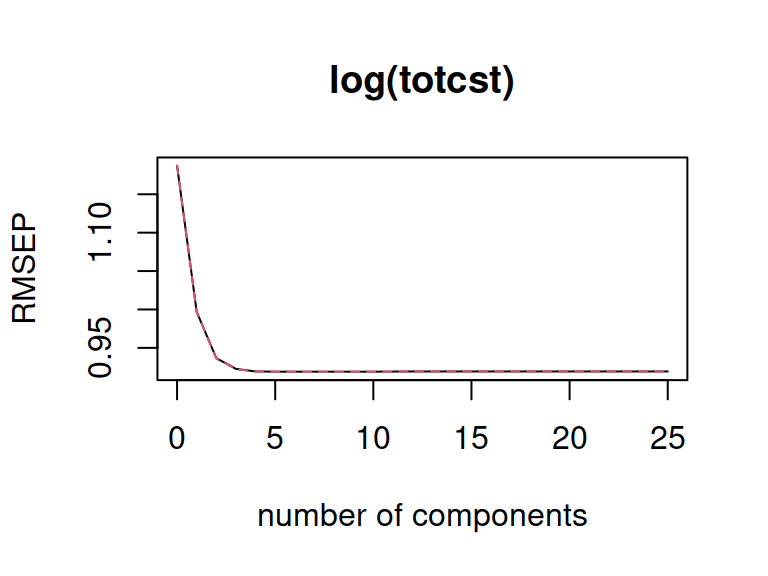

```r
validationplot(r.pls)
```

```r
# 6 or 7 components is the smallest number for several same CV errors
mse.pls = mean((log(d.support.test$totcst) - predict(r.pls, x.test, ncomp = 6))^2)
mse.pls
```

```
## [1] 0.8624827
```

It looks like by using $6$ or $7$ PCs in PLS we can get a somewhat lower prediction error than for ridge regression. PLS is thus the preferred method, although the difference is small.

## e)

```r
library(gam)
gam.fit = gam(log(totcst) ~ poly(age, degree = 2) + dzgroup + num.co + s(edu, df = 3) +
    income + poly(scoma, degree = 2) + race + ns(meanbp, df = 4) + ns(hrt, df = 4) +
    ns(resp, df = 4) + ns(temp, df = 4), data = d.support.train)

pred = predict(gam.fit, d.support.test)

mse.gam = mean((pred - log(d.support.test$totcst))^2)
mse.gam
```

```
## [1] 0.8291008
```

```r
d.support.train$dzgroup <- as.factor(d.support.train$dzgroup)
d.support.train$income <- as.factor(d.support.train$income)
d.support.train$race <- as.factor(d.support.train$race)

d.support.test$dzgroup <- as.factor(d.support.test$dzgroup)
d.support.test$income <- as.factor(d.support.test$income)
d.support.test$race <- as.factor(d.support.test$race)
```

```r
set.seed(4268)
library(gbm)
boost = gbm(log(totcst) ~ ., data = d.support.train, distribution = "gaussian", n.trees = 1000,
    interaction.depth = 4, shrinkage = 0.01)
yhat.boost = predict(boost, newdata = d.support.test, n.trees = 1000)
mse.boost = mean((log(d.support.test$totcst) - yhat.boost)^2)
mse.boost
```

```
## [1] 0.8201154
```

# Problem 4

## a)

See notes.

## b)

### i)

TRUE.

### ii)

TRUE.

### iii)

TRUE.

### iv)

FALSE.

## c)

### i)

FALSE.

### ii)

TRUE.

### iii)

TRUE.

### iv)

FALSE. It would be with replacement.

# Problem 5

### i)

TRUE.

### ii)

TRUE.

### iii)

FALSE.

### iv)

TRUE.

## b)

### i)

FALSE.

### ii)

TRUE.

### iii)

FALSE.

### iv)

TRUE.

## c)

4. The bias will steadily increase.

## d)

2. It means that the performance of the $K$-nearest neighbor classifier gets worse when the number of predictor variables $p$ is large.

## e)

1. $1.02\cdot10^{-7}$

## f)

### i)

TRUE.

### ii)

TRUE.

### iii)

FALSE.

### iv)

TRUE.

## g)

### i)

FALSEE The loading of PC2 is negative for 1500m, thus a negative value for this loading means that the athlete will run long times!

### ii)

TRUE. 100m and long jump lie on the same axis for PC1 and PC2 - just in opposite directions, because low times in 100m corresponds to high widths in long jump.

### iii)

TRUE, given that we look at the absolute values of the loadings.

### iv)

TRUE. 110m hurdle is almost parallel to PC1.